# Visualising Diffusion on FB100+FB1000-Networks

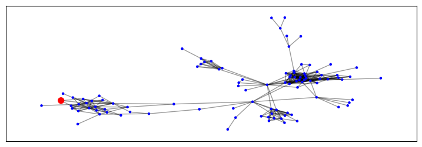

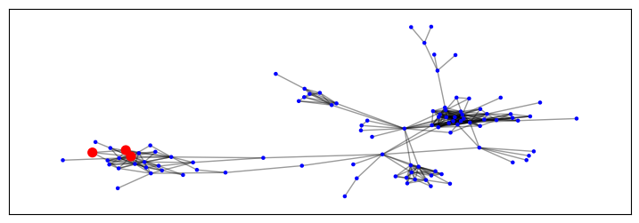

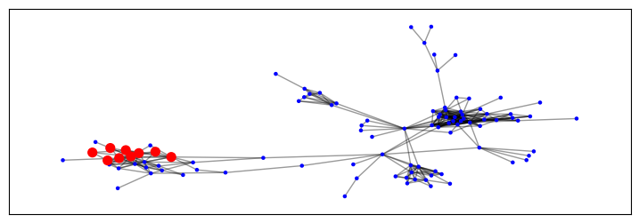

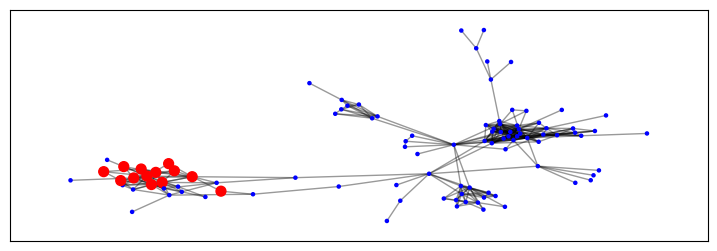

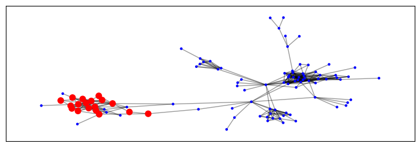

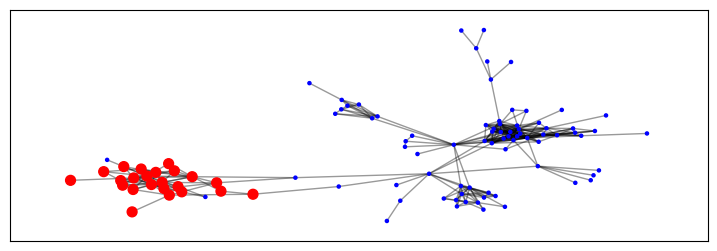

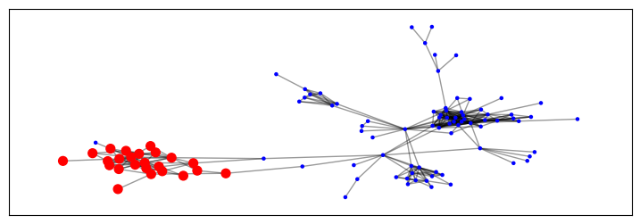

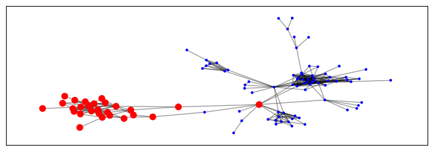

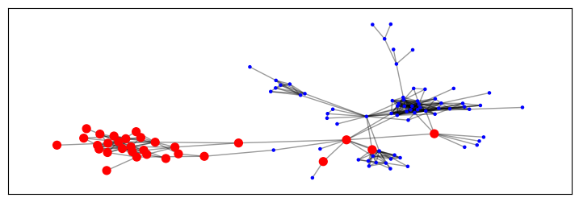

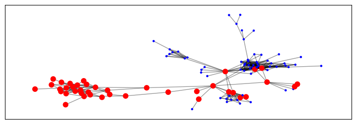

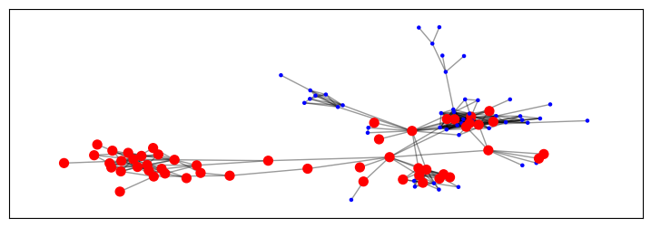

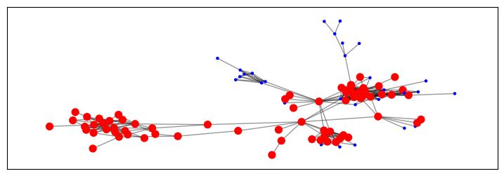

[5 more figures not shown]

```python
def diff_step(G):

    active_before = [x for x,y in G.nodes(data=True) if y['state'] == 1]

    n_active_before = len(active_before)

    for node in active_before:
        for (node, neighbor) in G.edges(node):
            #if (np.random.rand() <= G.edges[node, neighbor]['propagation_probability']) and (G.nodes[neighbor]['state'] != 2):
            if (np.random.rand() <= G.edges[node, neighbor]['propagation_probability']) and (G.nodes[neighbor]['state'] == 0):
                G.nodes[neighbor]['state'] = 1

    active_after = [x for x,y in G.nodes(data=True) if y['state'] == 1]

    n_active_after = len(active_after)

    return G

def v_spread(initial_infected, steps):

    blue = 'b'

    for i in range(steps):

        colormap = []
        sizemap = []

        for i in range(len(G.nodes())):
            colormap.append(blue)
            sizemap.append(5)

        active = [x for x,y in G.nodes(data=True) if y['state'] == 1]

        nodeindex = np.zeros(len(active))


        for i in range(len(active)):
            nodeindex[i] = int(np.where(node_array == active[i])[0])

        nodeindex = nodeindex.astype(np.int64)

        for i in range(len(active)):
            colormap[nodeindex[i]] = 'r'
            sizemap[nodeindex[i]] = 50

        Gcc = G.subgraph(sorted(nx.connected_components(G), key=len, reverse=True)[0])
        pos = nx.spring_layout(Gcc, seed=10396953)

        fig = plt.figure(figsize=(9, 3))

        nx.draw_networkx_nodes(Gcc, pos, node_color=colormap, node_size=sizemap)
        nx.draw_networkx_edges(Gcc, pos, alpha=0.4)

        diff_step(G)


initial_infected = '33'
G = initial_g(G, initial_infected)
v_spread(initial_infected, 20)
```

### Weighted FB1000-Network Distributions

```python
network = 'facebook_network1000.txt'
base_filename = os.path.splitext(os.path.basename(network))[0]
# env = SocialNetwork(network_file)

with open(network) as f:
    G = nx.Graph([line.split()[:2] for line in f])
print(G)
print(nx.is_connected(G))
print(nx.is_directed(G))

# Graph = nx.read_edgelist(network, create_using=nx.Graph(), nodetype=int)
# print(Graph)
# print(nx.is_connected(Graph))
# print(nx.is_directed(Graph))
# print(len(G.nodes()))
```

```
Graph with 1000 nodes and 10829 edges
True
False
```

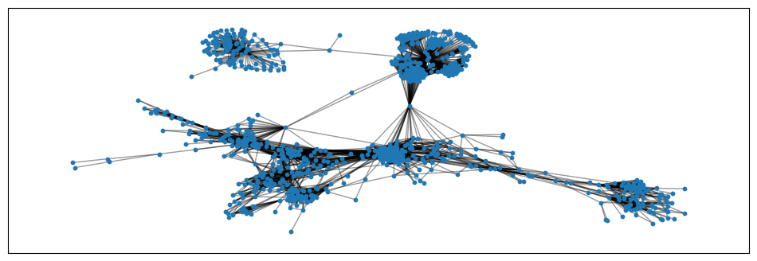

```python
degree_sequence = sorted((d for n, d in G.degree()), reverse=True)
dmax = max(degree_sequence)

fig = plt.figure(figsize=(12, 4))

Gcc = G.subgraph(sorted(nx.connected_components(G), key=len, reverse=True)[0])
pos = nx.spring_layout(Gcc, seed=10396953)
nx.draw_networkx_nodes(Gcc, pos, node_size=10)
nx.draw_networkx_edges(Gcc, pos, alpha=0.4)
```

IMPORTANT: For network-graphs with a large number of nodes, these visualisations can become misleading as to the graph-structure regarding the clustering of components, the bridges between them, and the general topological structure.

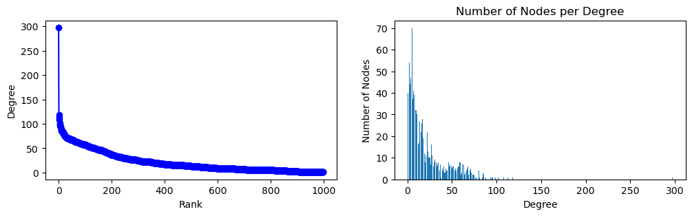

```python
f = plt.figure(figsize = (12, 3))

ax = plt.subplot(121)
ax.plot(degree_sequence, "b-", marker="o")
ax.set_ylabel("Degree")
ax.set_xlabel("Rank")

ax = plt.subplot(122)
ax.bar(*np.unique(degree_sequence, return_counts=True))
ax.set_title("Number of Nodes per Degree")
ax.set_xlabel("Degree")
ax.set_ylabel("Number of Nodes")

fig.tight_layout()
plt.show()
```

Note, the node with largest degree is around 300, more than twice the 2nd-highest degree.

```python
for n in G.nodes():
    G.nodes[n]['degree'] = G.degree(n)

#print(np.array(G.nodes('degree')))

node_array = np.array(G.nodes())
degree_array = np.zeros(len(G.nodes()))

for n in range(len(G.nodes())):
    degree_array[n] = np.array(G.nodes('degree'))[n, 1]
#print(degree_array)
```

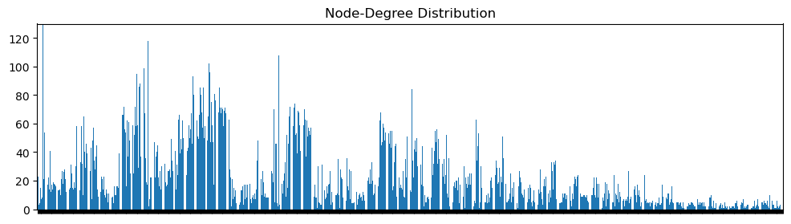

```python
fig, ax = plt.subplots(figsize=(12,3))
bars = ax.bar(node_array, degree_array, width=0.8)

ax.set_xlim(-0.5, len(node_array) - 0.5)

ax.set_ylim(0, 130)

ax.set_xticklabels([])

ax.set_title('Node-Degree Distribution')
plt.show()
```

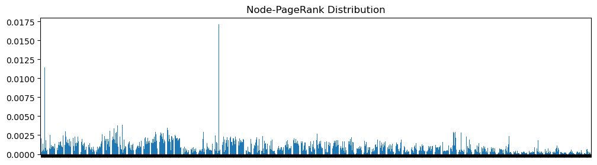

```python
random.seed(42) #Set seed

for (u, v) in G.edges():
    G.edges[u,v]['propagation_probability'] = random.uniform(0.1, 0.5)

pagerank = nx.pagerank(G, alpha = 0.98, weight = 'propagation_probability') # PageRank damping as close to 1 as possible to eliminate any randomness
pagerank_array = np.array([*pagerank.values()], dtype=object)

fig, ax = plt.subplots(figsize=(12,3))
bars = ax.bar(node_array, pagerank_array, width=0.8)

ax.set_xlim(-0.5, len(node_array) - 0.5)

#ax.set_ylim(0, 130)

ax.set_xticklabels([])

ax.set_title('Node-PageRank Distribution')
plt.show()
```

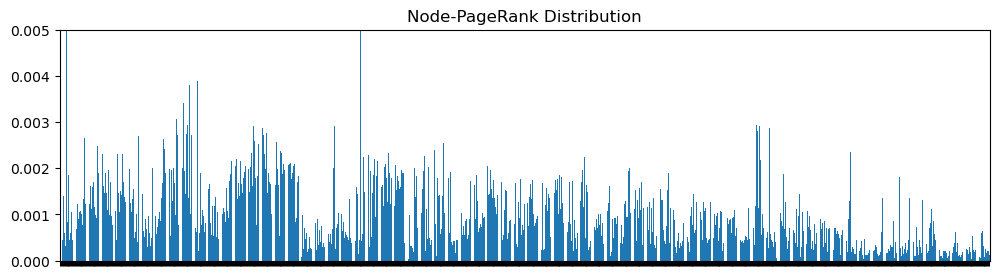

```python
pagerank = nx.pagerank(G, alpha = 0.98, weight = 'propagation_probability') # PageRank damping as close to 1 as possible to eliminate any randomness
pagerank_array = np.array([*pagerank.values()], dtype=object)

fig, ax = plt.subplots(figsize=(12,3))
bars = ax.bar(node_array, pagerank_array, width=0.8)

ax.set_xlim(-0.5, len(node_array) - 0.5)

ax.set_ylim(0, 0.005)

ax.set_xticklabels([])

ax.set_title('Node-PageRank Distribution')
plt.show()
```

For FB1000-network, there is a larger difference between PageRank and Degree node-distributions.

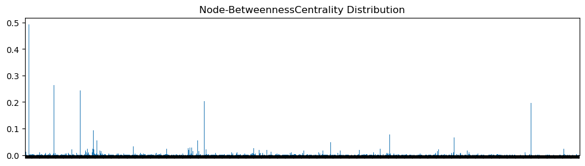

```python
bet_cent = nx.betweenness_centrality(G, weight = 'propagation_probability')
bet_cent_array = np.array([*bet_cent.values()], dtype=object)

fig, ax = plt.subplots(figsize=(12,3))
bars = ax.bar(node_array, bet_cent_array, width=0.8)

ax.set_xlim(-0.5, len(node_array) - 0.5)

#ax.set_ylim(0, 130)

ax.set_xticklabels([])

ax.set_title('Node-BetweennessCentrality Distribution')
plt.show()
```

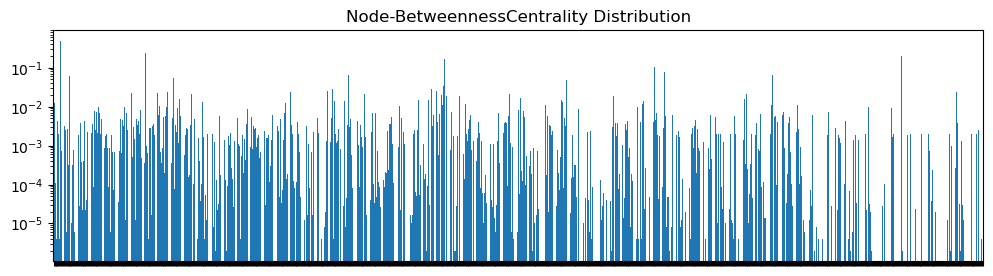

```python
fig, ax = plt.subplots(figsize=(12,3))
bars = ax.bar(node_array, bet_cent_array, width=0.8)

ax.set_xlim(-0.5, len(node_array) - 0.5)

ax.set_yscale('log')
ax.set_xticklabels([])

ax.set_title('Node-BetweennessCentrality Distribution')
plt.show()
```

```python
#Max PageRank Node
ind = np.argmax(pagerank_array)
print(node_array[ind])

max_val = np.max(pagerank_array)

#2nd-highest PageRank Node
pagerank_array[ind] = 0 #Temporarily set max-element to 0
ind2 = np.argmax(pagerank_array) #Index of 2nd-max element
pagerank_array[ind] = max_val #Replace max-element with original value

print(node_array[ind2])
```

```
311
585
```

```
Node 311:
Degree = 108
PageRank = 0.01717224189607258
BetweennessCentrality = 0.20304673410885837
```

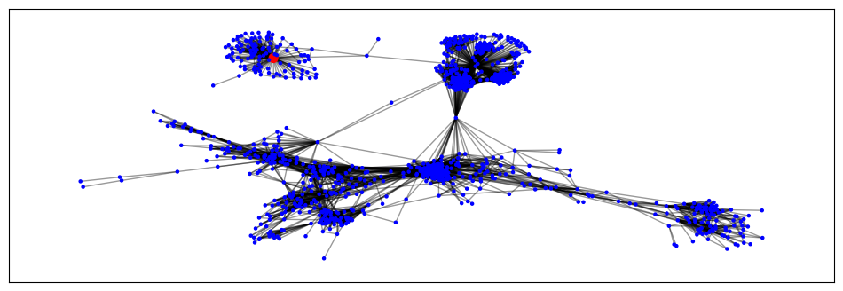

```python
v_initialnode('311')
```

```
Node 585:
Degree = 297
PageRank = 0.011462173137252374
BetweennessCentrality = 0.4936359204896279
```

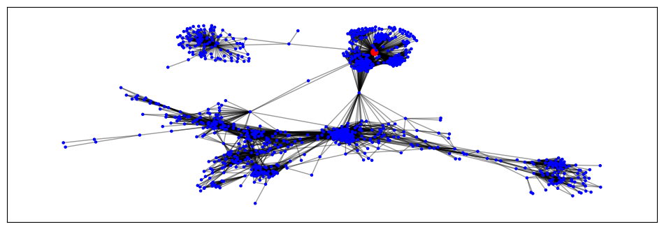

```python
v_initialnode('585')
```

```python
#Max BetweennessCentrality Node
ind = np.argmax(bet_cent_array)
print(node_array[ind])

max_val = np.max(bet_cent_array)

#2nd-highest BetweennessCentrality Node
bet_cent_array[ind] = 0 #Temporarily set max-element to 0
ind2 = np.argmax(bet_cent_array) #Index of 2nd-max element
bet_cent_array[ind] = max_val #Replace max-element with original value

print(node_array[ind2])
```

```
585
852
```

```
Node 585:
Degree = 297
PageRank = 0.011462173137252374
BetweennessCentrality = 0.4936359204896279
```

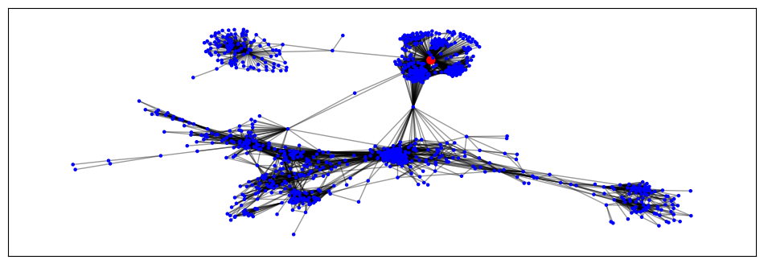

```python
v_initialnode('585')
```

```
Node 852:
Degree = 58
PageRank = 0.001960161033062345
BetweennessCentrality = 0.263610303690464
```

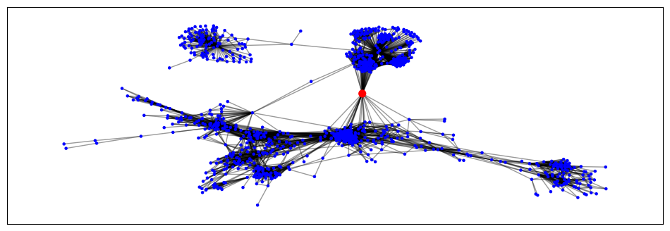

```python
v_initialnode('852')
```

On the FB1000-network, it can be seen (that for at least this initialisation of edge-weights), that the PageRank and BetweennessCentrality algorithms are distinct metrics in codifying the significance of nodes of the overall connected-ness of the networkgraph.

Identify 'Easy'-node intialisation:

```python
ind = np.where(degree_array == 3)
print(node_array[ind])
```

```
['547' '396' '423' '443' '479' '152' '333' '101' '759' '969' '632' '665'
 '533' '424' '743' '182' '369' '334' '195' '212' '766' '704' '564' '928'
 '787' '237' '517' '251' '734' '597' '957' '992' '313' '351' '978' '696'
 '405' '860' '415' '620' '527' '592' '945' '998']
```

```
Node 547:
Degree = 3
PageRank = 0.0002522788076601922
BetweennessCentrality = 0.00010832475762335481
```

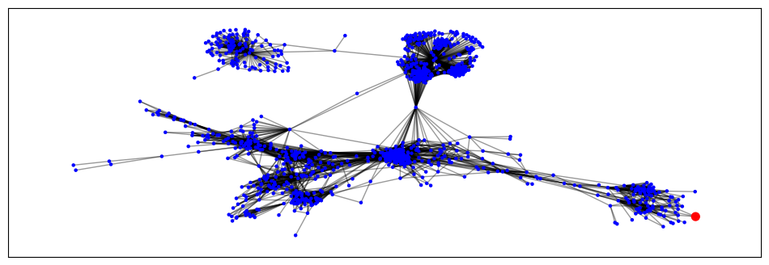

```python
v_initialnode('547')
```

### Visualising Baseline Infection-Spread ('Easy'-Initial Node)

```python
def diff_step(G):

    active_before = [x for x,y in G.nodes(data=True) if y['state'] == 1]

    n_active_before = len(active_before)

    for node in active_before:
        for (node, neighbor) in G.edges(node):
            #if (np.random.rand() <= G.edges[node, neighbor]['propagation_probability']) and (G.nodes[neighbor]['state'] != 2):
            if (np.random.rand() <= G.edges[node, neighbor]['propagation_probability']) and (G.nodes[neighbor]['state'] == 0):
                G.nodes[neighbor]['state'] = 1

    active_after = [x for x,y in G.nodes(data=True) if y['state'] == 1]

    n_active_after = len(active_after)

    return G, n_active_before, n_active_after
```

```python
network = 'facebook_network100.txt'
base_filename = os.path.splitext(os.path.basename(network))[0]

with open(network) as f:
    G1 = nx.Graph([line.split()[:2] for line in f])

network = 'facebook_network1000.txt'
base_filename = os.path.splitext(os.path.basename(network))[0]

with open(network) as f:
    G2 = nx.Graph([line.split()[:2] for line in f])

random.seed(42) #Set seed

for (u, v) in G1.edges():
    G1.edges[u,v]['propagation_probability'] = random.uniform(0.1, 0.5)
    #G1.edges[u,v]['propagation_probability'] = 1

for (u, v) in G2.edges():
    G2.edges[u,v]['propagation_probability'] = random.uniform(0.1, 0.5)
    #G2.edges[u,v]['propagation_probability'] = 1
```

```python
initial_infected = '33'
max_steps = 50
done = False


G1 = initial_g(G1, initial_infected)

count_active_step1 = []

step = 0

while not done:

    active = [x for x,y in G1.nodes(data=True) if y['state'] == 1]
    G_active = G1.subgraph(active)

    inactive = [x for x,y in G1.nodes(data=True) if y['state'] == 0]
    G_inactive = G1.subgraph(inactive)

    G1, n_active_before, n_active_after = diff_step(G1)

    count_active_step1.append(n_active_after)


    step += 1

    if step == max_steps:
        break

initial_infected = '547'
max_steps = 50
done = False


G2 = initial_g(G2, initial_infected)

count_active_step2 = []

step = 0

while not done:

    active = [x for x,y in G2.nodes(data=True) if y['state'] == 1]
    G_active = G2.subgraph(active)

    inactive = [x for x,y in G2.nodes(data=True) if y['state'] == 0]
    G_inactive = G2.subgraph(inactive)

    G2, n_active_before, n_active_after = diff_step(G2)

    count_active_step2.append(n_active_after)


    step += 1

    if step == max_steps:
        break
```

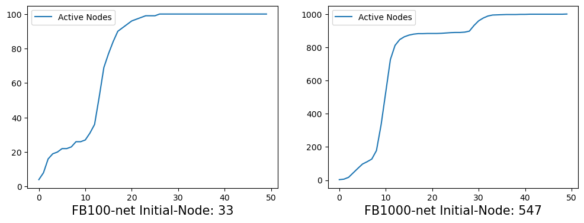

```python
fig = plt.figure(figsize=(12,4))

ax = fig.add_subplot(121)
ax.plot(count_active_step1, label = 'Active Nodes')

ax.set_xlabel(r'FB100-net Initial-Node: 33', fontsize=15)
plt.legend(loc=2)


ax = fig.add_subplot(122)
ax.plot(count_active_step2, label = 'Active Nodes')

ax.set_xlabel(r'FB1000-net Initial-Node: 547', fontsize=15)
plt.legend(loc=2)
```

### Visualising Baseline Infection-Spread ('Difficult'-Initial Node)

```python
initial_infected = '66'
max_steps = 50
done = False


G1 = initial_g(G1, initial_infected)

count_active_step1 = []

step = 0

while not done:

    active = [x for x,y in G1.nodes(data=True) if y['state'] == 1]
    G_active = G1.subgraph(active)

    inactive = [x for x,y in G1.nodes(data=True) if y['state'] == 0]
    G_inactive = G1.subgraph(inactive)

    G1, n_active_before, n_active_after = diff_step(G1)

    count_active_step1.append(n_active_after)


    step += 1

    if step == max_steps:
        break

initial_infected = '852'
max_steps = 50
done = False


G2 = initial_g(G2, initial_infected)

count_active_step2 = []

step = 0

while not done:

    active = [x for x,y in G2.nodes(data=True) if y['state'] == 1]
    G_active = G2.subgraph(active)

    inactive = [x for x,y in G2.nodes(data=True) if y['state'] == 0]
    G_inactive = G2.subgraph(inactive)

    G2, n_active_before, n_active_after = diff_step(G2)

    count_active_step2.append(n_active_after)


    step += 1

    if step == max_steps:
        break
```

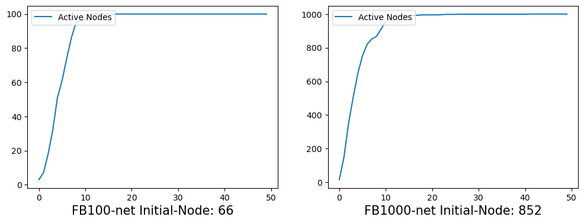

```python
fig = plt.figure(figsize=(12,4))

ax = fig.add_subplot(121)
ax.plot(count_active_step1, label = 'Active Nodes')

ax.set_xlabel(r'FB100-net Initial-Node: 66', fontsize=15)
plt.legend(loc=2)


ax = fig.add_subplot(122)
ax.plot(count_active_step2, label = 'Active Nodes')

ax.set_xlabel(r'FB1000-net Initial-Node: 852', fontsize=15)
plt.legend(loc=2)
```